# Simulation Tools and Sampling with Big Data

Acceptance-rejection method

Juan José Martín

## Método de Aceptación-Rechazo Simple

```r
simple_accept_reject_method = function(f, max_point, xdomain=c(0, 1), N=100000){
  if (N < 1){
    stop("N parameter must be greater than 1.")
  }

  Y_accepted = c()
  Y_rejected = c()

  for (i in 0:N){
    x = runif(1, xdomain[1], xdomain[2])
    fx = f(x)
    u = runif(1, 0, max_point)

    if (u <= fx){
        Y_accepted = c(Y_accepted, x)
    } else {
        Y_rejected = c(Y_rejected, x)
    }
  }

  r = list(Y_accepted, Y_rejected)
  return (r)
}
```

## Método de Aceptación-Rechazo General

```r
is_envelope_function = function(f, g, M, xdomain=c(0, 1), ...){
  if (xdomain[1] >= xdomain[2]){
    stop("First value of the xdomain must be lower than the second value.")
  }

  x = seq(xdomain[1], xdomain[2], by=0.01)
  y_base = f(x)
  y_envelope = g(x, ...)

  return (sum((y_envelope * M - y_base) < 0) == 0)
}
```

```r
plot_envelope_function = function(f, g, M, xdomain=c(0, 1), ...){
  if (xdomain[1] >= xdomain[2]){
    stop("First value of the xdomain must be lower than the second value.")
  }

  x = seq(xdomain[1], xdomain[2], by=0.01)
  y_base = f(x)
  y_envelope = g(x, ...) * M

  q1 = ggplot() + geom_line(aes(x=x, y=y_base, color='blue')) +
    geom_line(aes(x=x, y=y_envelope, color='red')) +
    theme(legend.position = 'right') +
    scale_color_manual(labels = c('Base function - f(x)', 'Envelope Function - g(x)'), values = c('blue', 'red')) +
    theme(legend.title=element_blank(),
          axis.title.x=element_blank(),
          axis.title.y=element_blank(),
          plot.title = element_text(hjust = 0.5))
  q1
}
```

```r
general_accept_reject_method = function(f, g, M, distrib_func, xdomain=NULL, N=100000, ...){
  if (N < 1){
    stop("N parameter must be greater than 1.")
  }

  Y_accepted = c()
  Y_rejected = c()

  y = distrib_func(n=N, ...)

  if (!is.null(xdomain)){
    if (xdomain[1] >= xdomain[2]){
        stop("First value of the xdomain must be lower than the second value.")
    }
    y = y[(y > xdomain[1]) & (y < xdomain[2])]
  }

  for (i in y){
    fy = f(i)
    gy = g(i, ...)
    u = runif(1, 0, 1)

    if (u <= fy / (M * gy)){
        Y_accepted = c(Y_accepted, i)
    } else {
        Y_rejected = c(Y_rejected, i)
    }
  }

  r = list(Y_accepted, Y_rejected)
  return (r)
}
```

## Ejercicios

**1. Simula mediante el método simple de aceptación−rechazo una variable aleatoria X con función de densidad $nf(x) = 20x(1 - x)^3n$ donde $x \in [0, 1]$.**

$$max \left\{20x(1 - x)^3\right\} = \frac{135}{64} \quad \text{en} \quad x = \frac{1}{4}$$

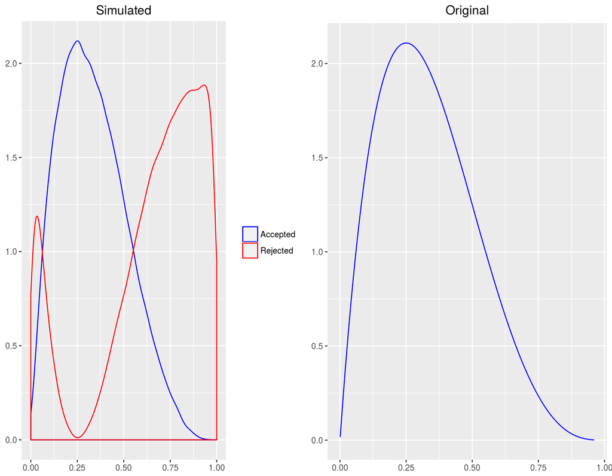

```r
f = function (x) 20 * x * (1 - x)**3
max_point = 135/64
N = 10**5

r = simple_accept_reject_method(f, max_point, N=N)
Y_accepted = r[[1]]
Y_rejected = r[[2]]

my_plot(Y_accepted, f, Y_rejected)
```

**2. Simula una variable aleatoria $X \sim \beta(3, 5)$ donde la función de densidad viene dada por:**

$$f_x = \left\{ \begin{array}{ll}{105x^2 (1-x)^4} & {\text{si }}{x \in (0,1)} \\ {0} & {\text{en otro caso}} \end{array} \right.$$

$$max \left\{105x^2 (1-x)^4\right\} = \frac{560}{243} \quad \text{en} \quad x = \frac{1}{3}$$

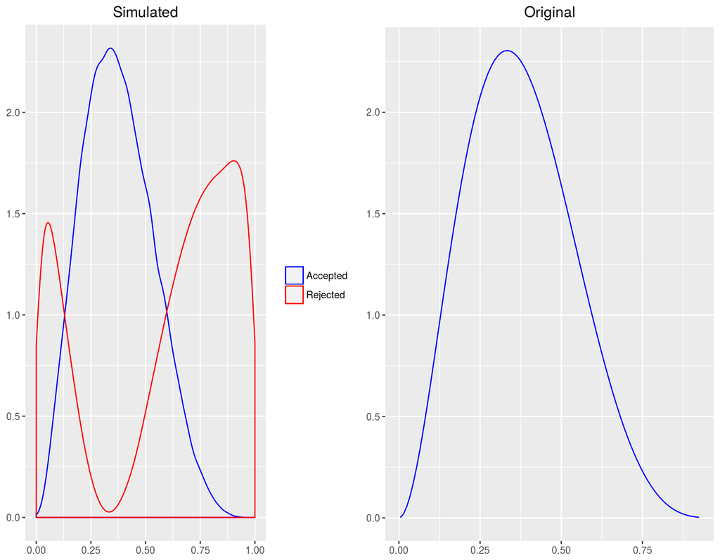

```r
f = function (x) 105 * (x**2) * ((1-x)**4)
max_point = 560/243
N = 10**5

r = simple_accept_reject_method(f, max_point, N=N)
Y_accepted = r[[1]]
Y_rejected = r[[2]]

my_plot(Y_accepted, f, Y_rejected)
```

**3. Aplica el método de aceptación−rechazo general para simular una variable aleatoria $X \sim N(0, 1)$ a partir de una $Y \sim Cauchy(0, 1)$.**

$$f_X(x) = \frac{1}{\sqrt{2\pi}} e^{\left(\frac{-x^2}{2}\right)}$$

$$g_Y(x) = \frac{1}{\pi (1 + x^2)}$$

para todo $x \in \mathbb{R}$. Veamos que existe $M \in (1, \infty)$ tal que $f_X(x) \leq M g_Y(x)$ para todo $x \in \mathbb{R}$. En efecto, la función

$$h(x) = \frac{\frac{1}{\sqrt{2\pi}} e^{\left(\frac{-x^2}{2}\right)}}{\frac{1}{\pi (1 + x^2)}}$$

admite los puntos críticos $x_1 = 0, x_2 = 1, x_3 = -1$ y alcanza el máximo en $x_2$ y $x_3$ con $h(1) = h(-1) = \sqrt{\frac{2\pi}{e}}$. Por lo tanto, $M = \sqrt{\frac{2\pi}{e}}$.

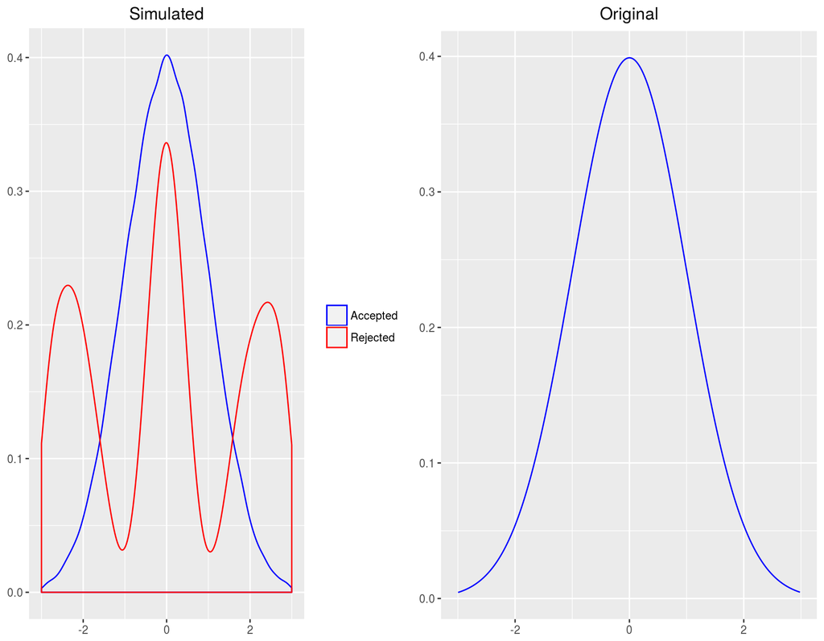

```r
f = function (x) (1 / sqrt(2 * pi)) * (exp(1)**((-x**2) / 2))
g = function (x) 1 / (pi * (1 + (x**2)))
M = sqrt((2 * pi) / exp(1))
N = 10**5

r = general_accept_reject_method(f, g, M,
                                 rcauchy,
                                 xdomain=c(-3, 3),
                                 N=N)
Y_accepted = r[[1]]
Y_rejected = r[[2]]

my_plot(Y_accepted, f, Y_rejected)
```

**4. Simula una variable aleatoria $X \sim N(0, 1)$ mediante una variable logística $Y \sim L(0, 1)$ como envolvente.**

$$f_X(x) = \frac{1}{\sqrt{2\pi}} e^{\left(\frac{-x^2}{2}\right)}$$

$$g_Y(x) = \frac{1}{(e^{-x} + 1)^2} e^{-x}$$

para todo $x \in \mathbb{R}$. Veamos que existe $M \in (1, \infty)$ tal que $f_X(x) \leq M g_Y(x)$ para todo $x \in \mathbb{R}$. En efecto, la función

$$h(x) = \frac{\frac{1}{\sqrt{2\pi}} e^{\left(\frac{-x^2}{2}\right)}}{\frac{1}{(e^{-x} + 1)^2} e^{-x}}$$

alcanza el máximo en $h(0) = 2 \sqrt{\frac{2}{\pi}}$. Por lo tanto, $M = 2 \sqrt{\frac{2}{\pi}}$.

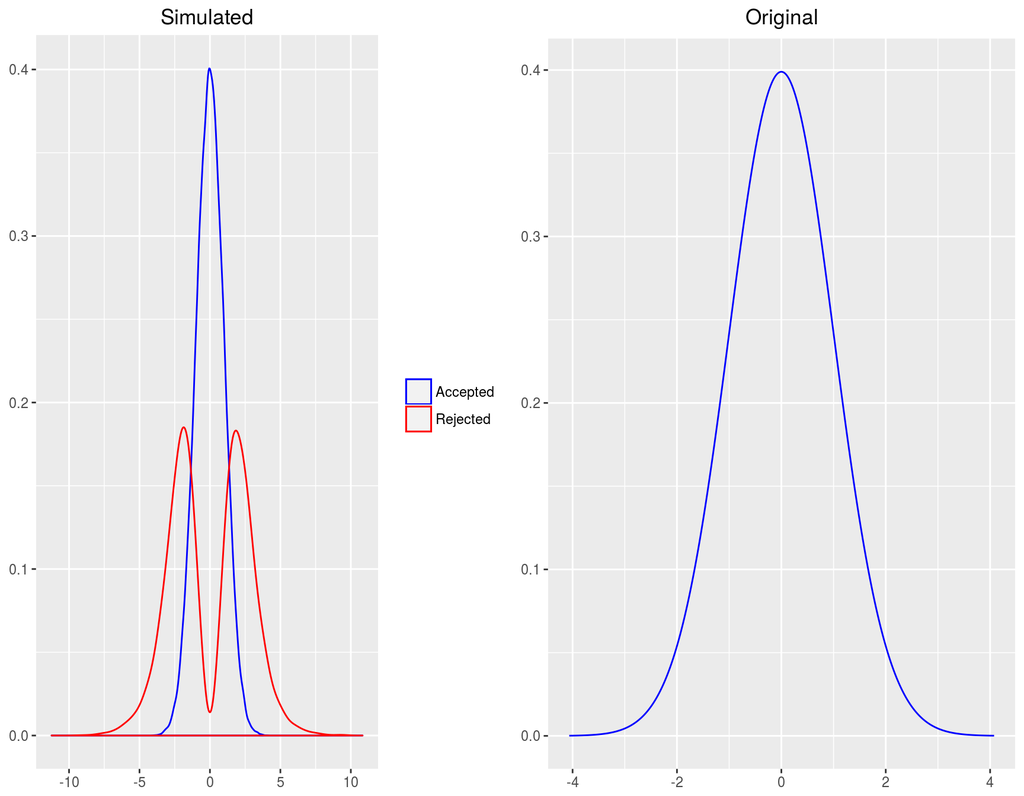

```r
f = function (x) (1 / sqrt(2 * pi)) * (exp(1)**((-x**2) / 2))
g = function (x) (1 / ((exp(1)**(-x)) + 1)**2) * (exp(1)**(-x))
M = 2 * sqrt(2 / pi)
N = 10**5

r = general_accept_reject_method(f, g, M,
                                 rlogis,
                                 N=N)
Y_accepted = r[[1]]
Y_rejected = r[[2]]

my_plot(Y_accepted, f, Y_rejected)
```

**5. Simula una variable aleatoria $X \sim \beta(2.7, 6.3)$ mediante otra variable beta $Y \sim \beta(2, 6)$ como envolvente.**

La función de densidad de una variable aleatoria $X \sim \beta(\alpha, \beta)$ viene dada por

$$f_X(\alpha, \beta) = \frac{x^{\alpha - 1} (1-x)^{\beta - 1}}{B(\alpha, \beta)} = \frac{x^{\alpha - 1} (1-x)^{\beta - 1}}{\frac{\Gamma(\alpha)\Gamma(\beta)}{\Gamma(\alpha + \beta)}}$$

donde

$$\Gamma(n) = (n - 1)!$$

Para las variables aleatorias $X \sim \beta(2.7, 6.3) \$ y $\ Y \sim \beta(2, 6)$, sus funciones de densidad vienen dadas por

$$f_X(x) = \left\{ \begin{array}{ll}{129.339 \ x^{1.7} (1-x)^{5.3}} & {\text{si }}{x \in (0,1)} \\ {0} & {\text{en otro caso}} \end{array} \right.$$

$$g_Y(x) = \left\{ \begin{array}{ll}{42 \ x (1-x)^5} & {\text{si }}{x \in (0,1)} \\ {0} & {\text{en otro caso}} \end{array} \right.$$

para todo $x \in \mathbb{R}$. Veamos que existe $M \in (1, \infty)$ tal que $f_X(x) \leq M g_Y(x)$ para todo $x \in \mathbb{R}$. En efecto, la función

$$h(x) = \frac{129.339 \ x^{1.7} (1-x)^{5.3}}{42 \ x (1-x)^5}$$

alcanza el máximo en $h(0.7) = 1.6718$. Por lo tanto, $M = 1.6718$.

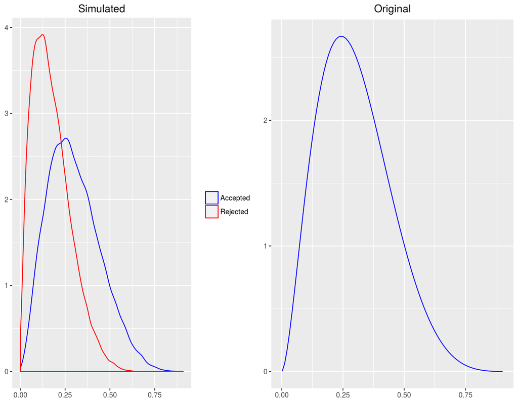

```r
f = function (x) 129.339 * (x**1.7) * ((1-x)**5.3)
g = function (x, shape1, shape2) 42 * x * ((1-x)**5)
M = 1.6718
N = 10**5

r = general_accept_reject_method(f, g, M,
                                 rbeta,
                                 N=N,
                                 shape1=2, shape2=6)
Y_accepted = r[[1]]
Y_rejected = r[[2]]

my_plot(Y_accepted, f, Y_rejected)
```

**6. La función de densidad**

$$f(x) = e^{(-x^2 / 2)} \ \ (sin((6x)^2) + 3 \ cos(x^2) \ sin((4x)^2) + 1)$$

**puede ser generada utilizando el algoritmo de aceptación - rechazo.**

**a) Comprueba gráficamente que $f(x)$ está acotada por $Mg(x)$, donde $g(x)$ es la densidad normal estándar $g(x) = \frac{e^{(-x^2 / 2)}}{\sqrt{2 \pi}}$. Encuentra un aceptable, no necesariamente óptimo, valor de $M$.**

```r
f = function (x) (exp(1)**(-x**2 / 2) * (sin(6*x)**2 + 3 * cos(x)**2 * sin(4*x)**2 + 1)) / 5.89434
g = function (x) (exp(1)**(-x**2 / 2) / sqrt(2 * pi)) # = st.norm.pdf
M = 1.8561

print(paste('¿Está f(x) acotada por Mg(x)? -->', is_envelope_function(f, g, M, xdomain=c(-4, 4))))
```

```
## [1] "¿Está f(x) acotada por Mg(x)? --> TRUE"
```

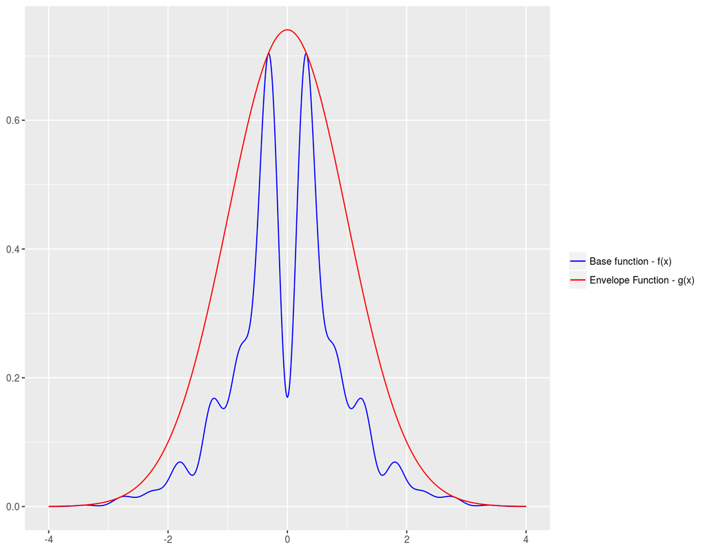

```r
plot_envelope_function(f, g, M, xdomain=c(-4, 4))
```

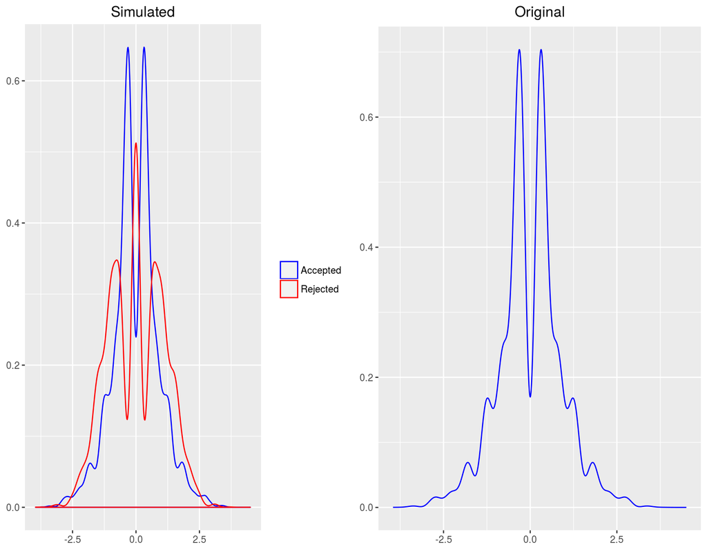

```r
N = 10**5

r = general_accept_reject_method(f, g, M,
                                 rnorm,
                                 N=N)
Y_accepted = r[[1]]
Y_rejected = r[[2]]

my_plot(Y_accepted, f, Y_rejected)
```